# Quantitative methods 2: Data analysis

SKOC39: Introduction to research methods  
and academic writing

nils.holmberg@iko.lu.se

## Quantitative methods

- 9. Experiments (and  
  Threats to Validity)
- 10. Survey Research,  
  Questionnaire
- 11. Quantitative  
  Content Analysis

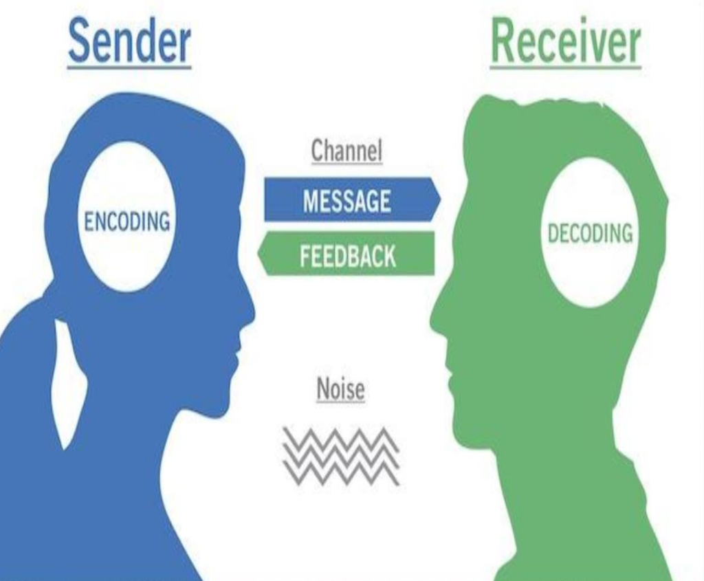

## Course literature

[figure not shown]

Boyle and Schmierbach (2015)

[figure not shown]

Boyle and Schmierbach (2019)

## Lectures and workshops

Data collection (nov 7)

- 5. Concept Explication and Measurement
- 6. Reliability and Validity
- 7. Effective Measurement
- 8. Sampling
- 11. Content Analysis

Exam question 1

Data analysis (nov 24)

- 9. Experiments (and Threats to Validity)
- 10. Survey Research
- 14. Descriptive Statistics
- 15. Inferential Statistics
- 16. Multivariate Statistics

Exam question 2

## AI use in academic papers

- OK: brainstorm ideas, do research
- OK: generate project materials
- OK: data analysis, statistics tools
- Not OK: copy-paste text to your exam
- Not OK: generate fake empirical data
- Not OK: upload content you dont own
- Not OK: upload data with personal info
- https://gemini.google.com/share/42360b8cb668
- https://aistudio.google.com/prompts/new_chat?model=gemini-2.5-pro

## Content analysis examples

- Political communication
- Swedish politicians using…
- Personalized social media…
- Effect on user engagement?
- Intervention and media use

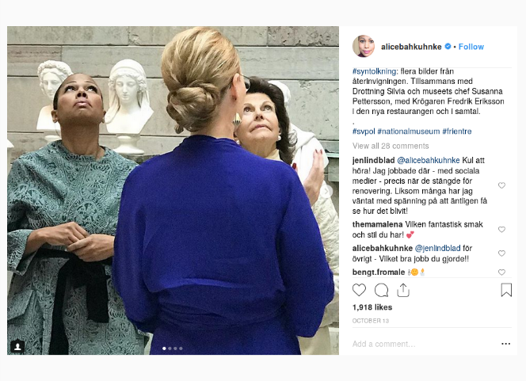

Chapter 10 – Survey Research Overview

## What Is Survey Research?

### Chapter 10 – Survey Research Overview

- Surveys collect answers to describe what people think or do
- Quick polls, tracking polls, and one-time surveys serve different needs
- Good sampling frames and strong response rates make results believable
- Interviewers and rapport can nudge answers—keep it neutral
- Example: Compare average job satisfaction vs support from the job survey

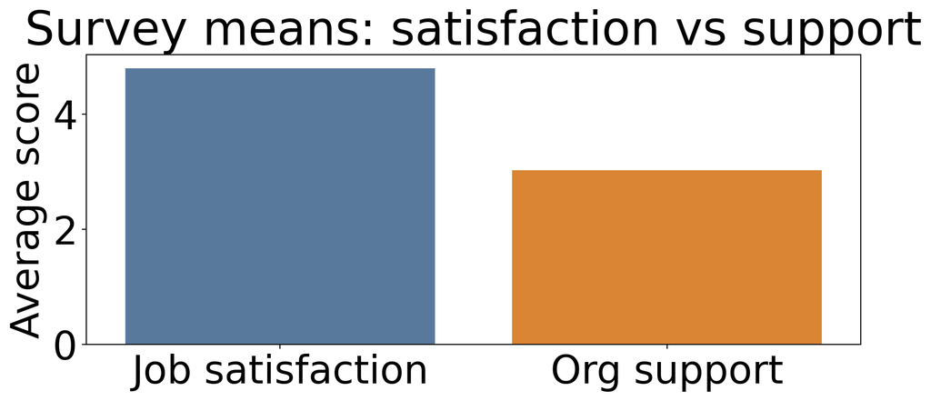

## Designing the Questionnaire

### Chapter 10 – Survey Research Overview

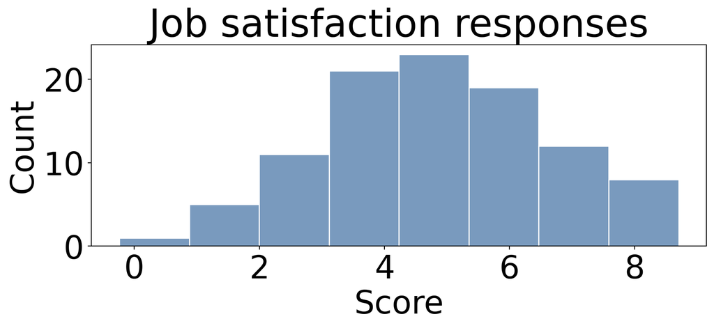

## Longitudinal Approaches

### Chapter 10 – Survey Research Overview

- Cohort, trend, and panel studies track change over time in different ways
- Attrition (people dropping out) can tilt results
- Repeated surveys can change how people answer
- Keep in touch and make participation easy to reduce drop-off
- Example: Re-survey this job group later to see if satisfaction links to performance change

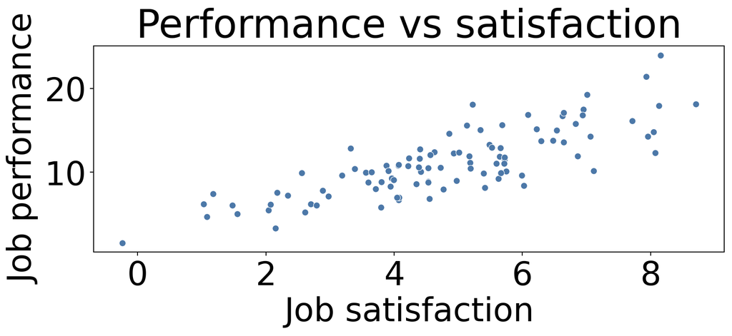

## Fieldwork & Quality

### Chapter 10 – Survey Research Overview

- Train staff and stick to the script so tone stays consistent
- Watch response logs to spot problems early
- Different modes (phone, web) can bias who answers—plan for it
- Be open about weighting, limits, and privacy steps
- Example: Check if High/Low support and satisfaction cells are balanced in the job survey

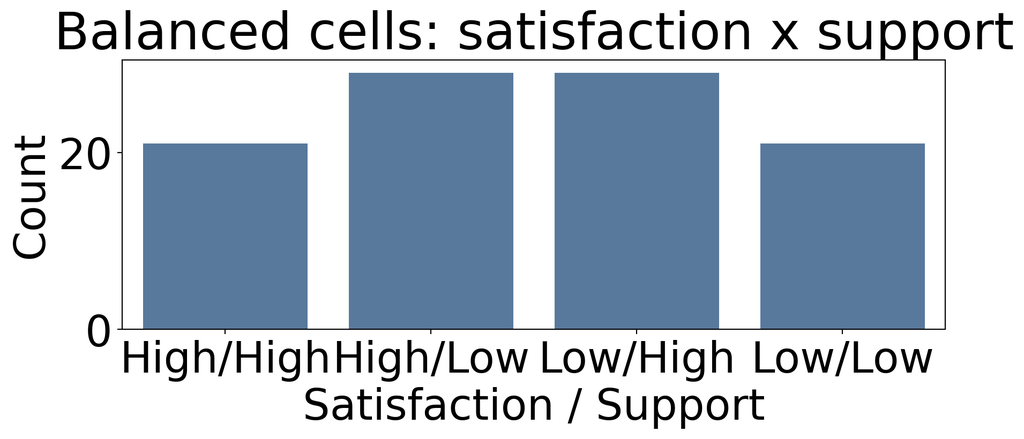

Chapter 9 – Experiments & Threats to Validity

## Experiment examples

| Section | Variables |
| --- | --- |
| **1. demographic background** | - age - gender |
| **2. explanatory variables** | - theory |
| **3. experimental conditions** | - control - treatment |
| **4. outcome variables** | - trust - intention |

- link to experiment [youtube video](https://www.youtube.com/watch?v=D23f5eO8n7U&mode=theatre)
- link to experiment [dataset](https://raw.githubusercontent.com/nils-holmberg/osm-exp/refs/heads/main/csv/exps-data.tsv)
- link to experiment [analysis](https://gemini.google.com/share/6c2946eb8bf7)

[figure not shown]

## Experimental Basics

### Chapter 9 – Experiments & Threats to Validity

- An experiment tests a treatment against a control
- Between-subjects = different groups; within-subjects = same people twice
- Quasi-experiments skip random assignment, so be careful
- Double-blind setups cut bias from both participants and researchers
- Example: Compare control vs treatment conditions on attitude in `exps-data.tsv`

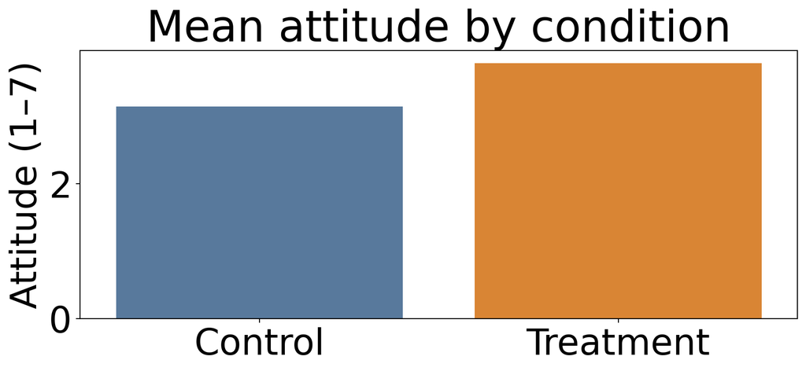

## Assignment & Design Choices

### Chapter 9 – Experiments & Threats to Validity

- Random assignment mixes people so groups start equal
- Matching pairs is a backup when you can’t randomize perfectly
- Watch for selection bias when groups self-select
- Field experiments feel real; lab experiments give tight control
- Example: Check condition counts in `exps-data.tsv` to see if groups stayed balanced

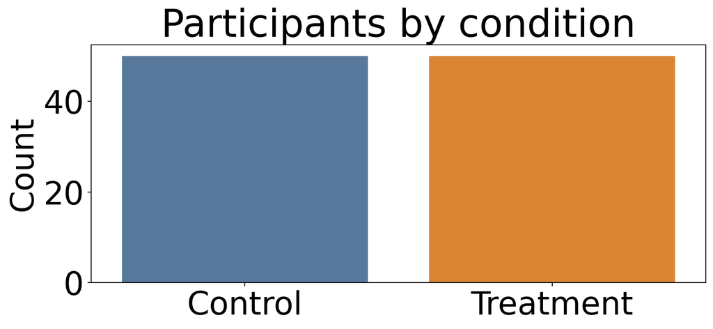

## Advantages vs Disadvantages

### Chapter 9 – Experiments & Threats to Validity

- Pro: Clearer cause-and-effect and easy to repeat
- Con: Setups can feel fake or costly to run
- Keep measures short and reliable to respect participants
- Pilot the steps to fix issues before launch
- Example: Compare attitude spread in control vs treatment from `exps-data.tsv`

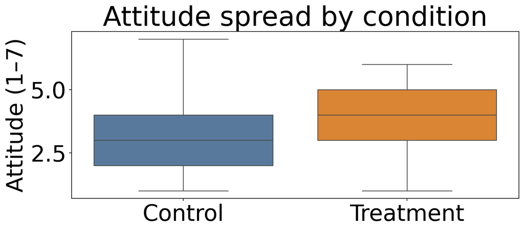

## Threats to Validity

### Chapter 9 – Experiments & Threats to Validity

- People may act differently when watched (Hawthorne) or drop out
- Outside events, maturation, or extreme scores can skew results
- Bias can come from researchers or participants talking
- Repeated testing can change answers over time
- Example: Track attitude over time in `exps-data.tsv` to spot mid-study shifts

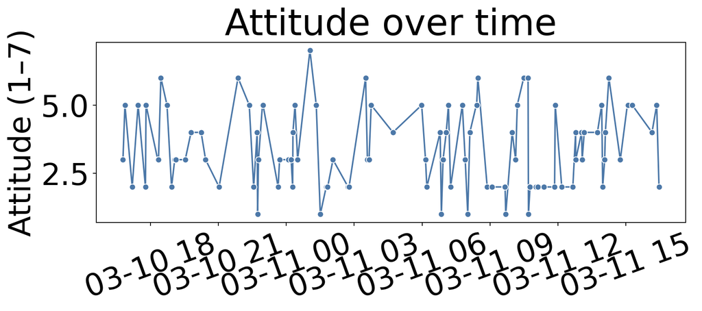

## Data Analysis Software

- https://www.jamovi.org/download.html
- [link to dataset](https://raw.githubusercontent.com/nils-holmberg/osm-exp/refs/heads/main/csv/exps-data.tsv)

[figure not shown]

Chapter 14 – Descriptive Statistics

## Purpose of Description

### Chapter 14 – Descriptive Statistics

- Describe the data first to see patterns
- Pick stats that fit the type of variable
- Look for typos or weird values before trusting results
- Use simple charts to show what numbers mean
- Example: Plot attitude scores from `exps-data.tsv` to spot any odd spikes

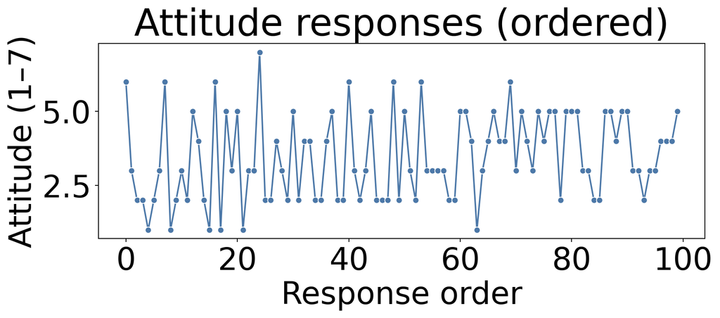

## Central Tendency

### Chapter 14 – Descriptive Statistics

- Mean = average, median = middle, mode = most common
- Means move a lot when outliers appear
- Medians stay steady when data are skewed
- Modes help with categories like “favorite platform”
- Example: Compare mean vs median attitude from `exps-data.tsv`

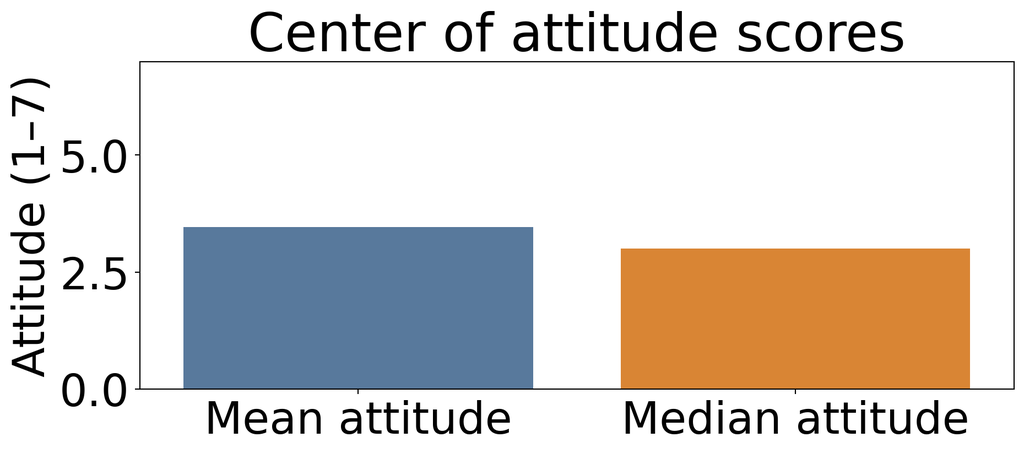

## Dispersion

### Chapter 14 – Descriptive Statistics

- Range is min to max; standard deviation shows typical spread
- More spread means less certainty about the “typical” case
- Interquartile range handles skewed data better
- Check outliers so one odd day doesn’t distort the story
- Example: Show attitude spread and look for outliers in `exps-data.tsv`

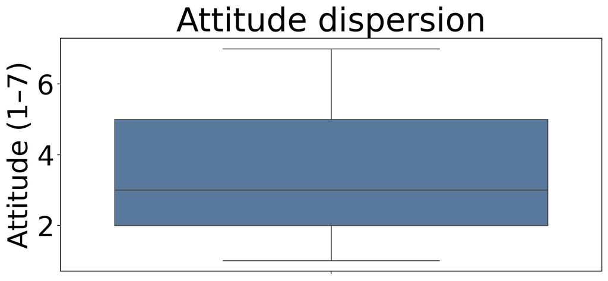

## Distributions & Shapes

### Chapter 14 – Descriptive Statistics

- Histograms show how values pile up or spread out
- Spot skew: long tail right or left; flat vs peaked shapes
- Ceiling or floor effects happen when scores bunch at the top or bottom
- Z-scores compare values on the same scale
- Example: Histogram of attention scores from `exps-data.tsv`

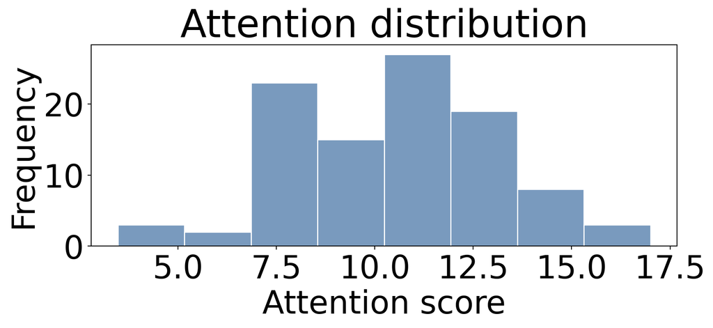

Chapter 15 – Inferential Statistics

## Logic of Inference

### Chapter 15 – Inferential Statistics

- We sample a few people to say something about many, with uncertainty
- Null = “no effect,” alternative = “there is an effect”
- P-values show how surprising results are if the null is true
- Type I = false alarm; Type II = missed real effect
- Example: Test if the treatment boosts attitude vs control in `exps-data.tsv`

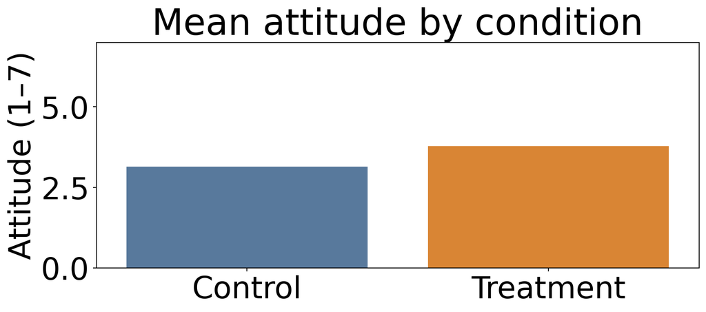

## Effect Size & Power

### Chapter 15 – Inferential Statistics

- Effect size tells how big the difference really is
- Power rises with bigger samples and clearer signals
- Lower alpha or many tests make it harder to detect effects
- Plan sample size before collecting data
- Example: Treatment minus control attitude difference from `exps-data.tsv`

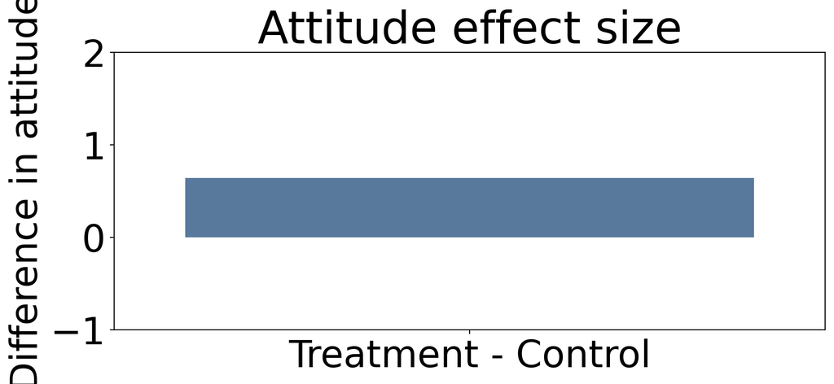

## Common Tests

### Chapter 15 – Inferential Statistics

- Chi-square checks links between categories
- T-tests compare two means; ANOVA compares many
- Correlation (r) shows how two numbers move together
- Check basic assumptions so results are trustworthy
- Example: Correlate attention and attitude in `exps-data.tsv`

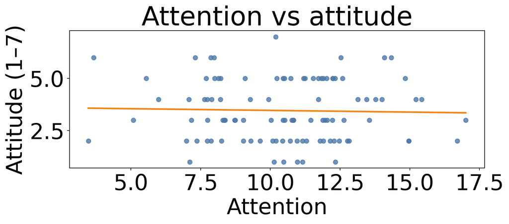

## Reporting & Interpretation

### Chapter 15 – Inferential Statistics

- Share estimates with confidence intervals, not just p-values
- Focus on size and direction, not only “significant” labels
- Run simple checks to see if results hold up
- Be open about limits and any multiple tests you ran
- Example: Report mean attitude with 95% CI for each condition in `exps-data.tsv`

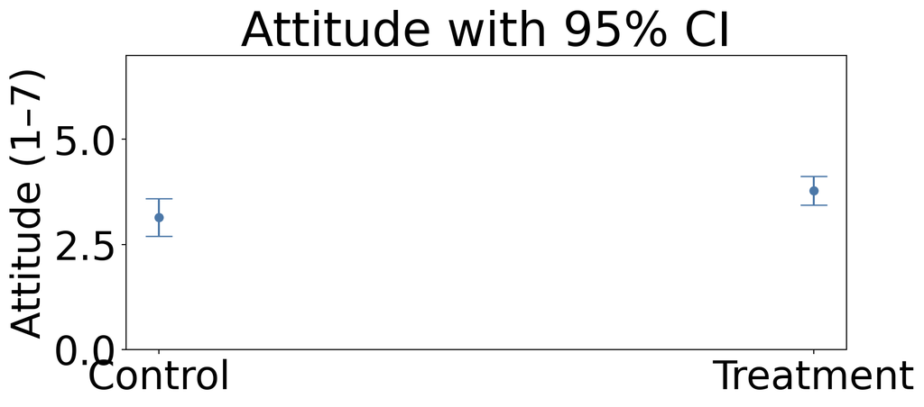

Chapter 16 – Multivariate Statistics

## Why Multivariate?

### Chapter 16 – Multivariate Statistics

- Multiple variables let us control for other factors
- Spurious links fade when we add the right controls
- Interactions show when one effect depends on another
- Pick methods that fit the data and assumptions
- Example: See if job satisfaction still predicts performance after accounting for support

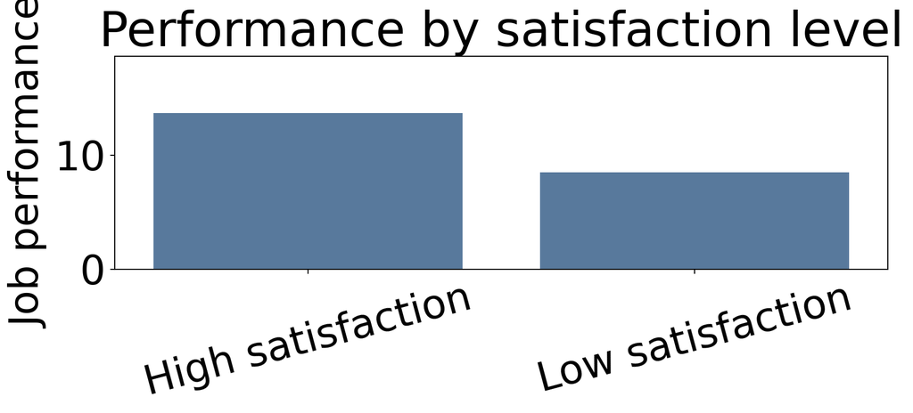

## Regression Foundations

### Chapter 16 – Multivariate Statistics

- Linear regression predicts an outcome from predictors
- Coefficients show direction and size of the link
- R2 tells how much variation the model explains
- Check residual plots to see if the line fit makes sense
- Example: Predict performance from satisfaction and support scores

[figure not shown]

## Multivariate ANOVA Family

### Chapter 16 – Multivariate Statistics

- Two-way ANOVA tests two factors at once
- ANCOVA adjusts for a covariate while comparing groups
- MANOVA handles several outcomes together
- Look for interactions to see if effects change by group
- Example: Performance by satisfaction and support groups (Job_Performance_Dataset.tsv)

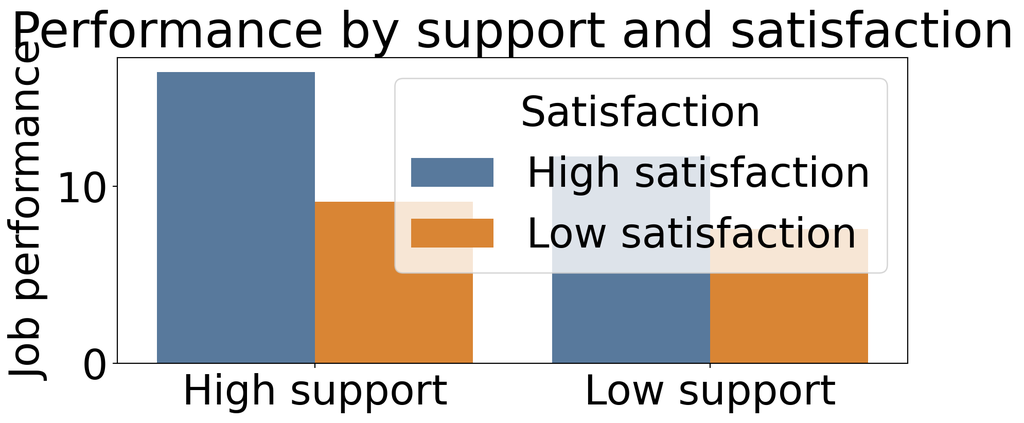

## Practice & Reporting

### Chapter 16 – Multivariate Statistics

- Write down how you chose and coded variables
- Check assumptions and share the diagnostics
- Use plots to show interactions and model fit
- Talk about real-world size, not just model numbers
- Example: Show how performance moves with both satisfaction and support scores

[figure not shown]

## Next steps

**Workshop 1, nov 18**

- Content databases, e.g.: https://app.retriever-info.com/
- Coding scheme, survey: https://survey.mailing.lu.se/Admin/

**Lecture 2, nov 24**

- Data analysis software: https://www.jamovi.org/download.html

**References**

Boyle, Michael, and Mike Schmierbach. 2015. *Applied Communication Research Methods: Getting Started as a Researcher*. Routledge.

———. 2019. *Applied Communication Research Methods: Getting Started as a Researcher*. Routledge.